# Data Import

As a first step we load several packages we need, and download data from the SQL database.

```r
require (MASS)
require (RODBC)
require (lubridate)
require (ggplot2)
require (sqldf)
require (dplyr)

channel <- odbcDriverConnect(connection = "DRIVER={SQL Server}; SERVER=DBACM\\ARCHIMEDES; DATABASE=LoadForecastingAnalytics")
data <- sqlQuery(channel, "SELECT * FROM ##OurData")

## delete Caledar month from initial data, you don't need it
#data$CalendarMonth <- NULL
#data$TwoSeasons <- ifelse(data$Season %in% c('Spring','Summer'),'SummerSeason','WinterSeason')
```

# Normalizing the volumes

Firstly we create the table Stat that for each account number will have its mean and standard deviation.

```r
Mean <- aggregate(DailyVolume~AccountNumberOID,data=data,FUN=mean)
names(Mean)[2] <- 'MeanVolume'
Std <- aggregate(DailyVolume~AccountNumberOID,data=data,FUN=sd)
names(Std)[2] <- 'StandardDev'

Stat <- cbind(Mean, Std$StandardDev)
names(Stat)[3] <- 'StandardDev'
head(Stat)
```

```
##   AccountNumberOID MeanVolume StandardDev
## 1          1534027  18.274603   5.8492102
## 2          1534032   4.678454   1.4709379
## 3          1534033  12.587353   3.5315759
## 4          1534457   2.311778   0.8118384
## 5          1535238  15.091061   3.0700753
## 6          1535239  18.489933   3.5460031
```

Then we join our data table to the table Stat on AccountNumberOID, and calculate normalized volumes for every account.

```r
data <- merge (data, Stat, by = 'AccountNumberOID')
data$NormalizedDailyVolume <- (data$DailyVolume - data$MeanVolume)/ data$StandardDev
head(data)
```

```
##   AccountNumberOID LDCAccountIdentifier LDCIdentifier
## 1          1534027         2.113121e+14             8
## 2          1534027         2.113121e+14             8
## 3          1534027         2.113121e+14             8
## 4          1534027         2.113121e+14             8
## 5          1534027         2.113121e+14             8
## 6          1534027         2.113121e+14             8
##   SourceSystemIdentifier CalendarMonth DailyVolume StationCode StationOID
## 1                  GBASS    2014-07-01    33.48824        KNYC         14
## 2                  GBASS    2014-02-01    16.94868        KNYC         14
## 3                  GBASS    2015-06-01    16.97761        KNYC         14
## 4                  GBASS    2015-05-01    12.05996        KNYC         14
## 5                  GBASS    2015-06-01    16.97761        KNYC         14
## 6                  GBASS    2015-01-01    17.63802        KNYC         14
##   Season AverageTemperature AverageDailyDewPointTemperature
```

[output cut: 34 more lines]

# Model Selection

Firstly, we fit initial model for the stepwise regression.

```r
fit_all <- lm(NormalizedDailyVolume ~ 1, data = data)
summary(fit_all)
```

```
##
## Call:
## lm(formula = NormalizedDailyVolume ~ 1, data = data)
##
## Residuals:
##     Min      1Q  Median      3Q     Max
## -4.3339 -0.6991 -0.2108  0.6064  5.1300
##
## Coefficients:
##              Estimate Std. Error t value Pr(>|t|)
## (Intercept) 3.412e-16  2.299e-03       0        1
##
## Residual standard error: 0.9816 on 182284 degrees of freedom
```

Then we run bidirectional stepwise regression in order to choose only important parameters for our model. For now we are using only two weather parameters, we will test the others later. This model selection is run for all the accounts together, and then we are going to fit every account individually using the selected model.

```r
stepAIC (fit_all, direct = 'both', scope = list(upper = ~ AverageDailyHeatingDegreeDays +
                                                  AverageDailyCoolingDegreeDays, low = ~1))
```

```
## Start:  AIC=-6766.11
## NormalizedDailyVolume ~ 1
##
##                                 Df Sum of Sq    RSS    AIC
## + AverageDailyCoolingDegreeDays  1     31985 143656 -43408
## + AverageDailyHeatingDegreeDays  1      6986 168655 -14162
## <none>                                       175641  -6766
##
## Step:  AIC=-43407.76
## NormalizedDailyVolume ~ AverageDailyCoolingDegreeDays
##
##                                 Df Sum of Sq    RSS    AIC
## + AverageDailyHeatingDegreeDays  1      6021 137635 -51211
## <none>                                       143656 -43408
## - AverageDailyCoolingDegreeDays  1     31985 175641  -6766
##
## Step:  AIC=-51210.56
## NormalizedDailyVolume ~ AverageDailyCoolingDegreeDays + AverageDailyHeatingDegreeDays
##
##                                 Df Sum of Sq    RSS    AIC
## <none>                                       137635 -51211
## - AverageDailyHeatingDegreeDays  1      6021 143656 -43408
## - AverageDailyCoolingDegreeDays  1     31021 168655 -14162
```

```
##
## Call:
## lm(formula = NormalizedDailyVolume ~ AverageDailyCoolingDegreeDays +
##     AverageDailyHeatingDegreeDays, data = data)
##
## Coefficients:
##                   (Intercept)  AverageDailyCoolingDegreeDays
##                      -0.74835                        0.14958
## AverageDailyHeatingDegreeDays
##                       0.02016
```

Fit the model for all accounts together. This is for demonstration purpose only. We are not going to use these coefficients, as we will build different models for each account.

```r
aic_fit_all <- lm(NormalizedDailyVolume ~ AverageDailyHeatingDegreeDays +
                    AverageDailyCoolingDegreeDays, data = data)
summary(aic_fit_all)
```

```
##
## Call:
## lm(formula = NormalizedDailyVolume ~ AverageDailyHeatingDegreeDays +
##     AverageDailyCoolingDegreeDays, data = data)
##
## Residuals:
##     Min      1Q  Median      3Q     Max
## -5.6169 -0.5543 -0.0965  0.5378  5.1087
##
## Coefficients:
##                                 Estimate Std. Error t value Pr(>|t|)
## (Intercept)                   -0.7483496  0.0056312  -132.9   <2e-16 ***
## AverageDailyHeatingDegreeDays  0.0201638  0.0002258    89.3   <2e-16 ***
## AverageDailyCoolingDegreeDays  0.1495789  0.0007380   202.7   <2e-16 ***
## ---
## Signif. codes:  0 '***' 0.001 '**' 0.01 '*' 0.05 '.' 0.1 ' ' 1
##
## Residual standard error: 0.8689 on 182282 degrees of freedom
## Multiple R-squared:  0.2164, Adjusted R-squared:  0.2164
## F-statistic: 2.517e+04 on 2 and 182282 DF,  p-value: < 2.2e-16
```

# Fitting selected model every account individually

Since we have many (around 27,000) account numbers in our data, it can take a long time for R to process all of them. So for now we just want to try to build models for the first 7,000 accounts.

```r
#set.seed(1) # so random result would be the same every time you run
#data_testing <- subset (data, AccountNumberOID %in% sample(unique(data$AccountNumberOID),1000))
data_testing <- subset (data, AccountNumberOID %in% unique(data$AccountNumberOID)[1:7000])
```

Now we split the data by account number, creating a list of account numbers, each with its own data frame.

```r
data_split <- split(data_testing, data_testing$AccountNumberOID)
head(data_split,1)
```

```
## $`1534027`
##    AccountNumberOID LDCAccountIdentifier LDCIdentifier
## 1           1534027         2.113121e+14             8
## 2           1534027         2.113121e+14             8
## 3           1534027         2.113121e+14             8
## 4           1534027         2.113121e+14             8
## 5           1534027         2.113121e+14             8
## 6           1534027         2.113121e+14             8
## 7           1534027         2.113121e+14             8
## 8           1534027         2.113121e+14             8
## 9           1534027         2.113121e+14             8
## 10          1534027         2.113121e+14             8
## 11          1534027         2.113121e+14             8
## 12          1534027         2.113121e+14             8
## 13          1534027         2.113121e+14             8
```

[output cut: 168 more lines]

Now we use lapply function in order to fit the models for all accounts.

```r
account_fits <- lapply(data_split, lm, formula = DailyVolume ~ AverageDailyCoolingDegreeDays + AverageDailyHeatingDegreeDays )
head(account_fits,2)
```

```
## $`1534027`
##
## Call:
## FUN(formula = ..1, data = X[[1L]])
##
## Coefficients:
##                   (Intercept)  AverageDailyCoolingDegreeDays
##                        9.6641                         1.5739
## AverageDailyHeatingDegreeDays
##                        0.2647
##
##
## $`1534032`
##
## Call:
## FUN(formula = ..1, data = X[[2L]])
##
## Coefficients:
##                   (Intercept)  AverageDailyCoolingDegreeDays
##                        2.9127                         0.3868
## AverageDailyHeatingDegreeDays
##                        0.0402
```

# Analysis of models

## Determining R Squared and p-value For each individual account model

Now, after we fit all models for every account number, we want to analyze them and check how good they are. We create a data frame, that we call “model_stats”, that for every account number will show p-value for F-test and R squared.

```r
##Analysis of the model
extract_rsq <- function(fits){

    model_stats <- data.frame()
    for (i in 1:length(fits)){

    f <- summary(fits[[i]])$fstatistic
    #calculate p-value
    pvalue <- 1-pf(f[1],f[2],f[3])
    r_sq <- summary(fits[[i]])$adj.r.squared

    model_stats<-rbind(model_stats,cbind(data_split[[i]]$AccountNumberOID[1],pvalue,r_sq))

  }
  rownames(model_stats) <- NULL
  names(model_stats)[1] <- 'AccountNumberOID'

  return(model_stats)
}

model_stats <- extract_rsq(account_fits)
```

## Weather-sensetive Accounts

We want to create regression model only for those account numbers, for which weather has significant impact on the usage. So we filter only for the accounts that have p-value for F-statistics less than 5%.

```r
#model_stats_weather_dependant <- subset(model_stats, pvalue < 0.05)

#let's include all for now, just to test
model_stats_weather_dependant <- model_stats
```

Total number of accounts is 6644, number of weather-sensetive accounts is 6644, which gives us **100.00% of weather sensetive accounts**, that we want to use regression model for.

See below plots that demonstarte R squared distribution for weather dependant account:

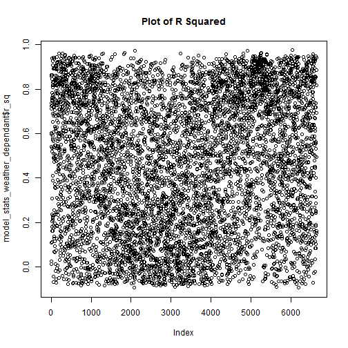

```r
plot(model_stats_weather_dependant$r_sq, main = 'Plot of R Squared')
```

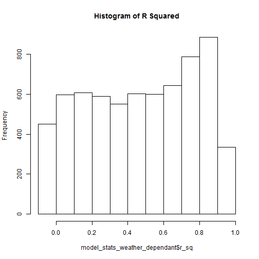

```r
hist(model_stats_weather_dependant$r_sq, main = 'Histogram of R Squared', breaks= 15)
```

```r
#mean(model_stats_weather_dependant$r_sq)
#median(model_stats_weather_dependant$r_sq)
```

## MAPE calculation

The result above shows us analysis of R sq, but we want to understand it in term of MAPEs. For our model we would like to get an accuracy of 6%, so our main question at this point is what kind of R sq we need to have in order to get 6% of MAPE.

To calculate MAPEs for every account, we need to find actual, and backcasted volumes.

```r
accounts_backcast <- lapply (account_fits, predict)
# fit$dataframe is the data frame for the fit. first column is Y-variable

#accounts_actual    <- subset (data_testing, select=c(AccountNumberOID,DailyVolume,CalendarMonth))
accounts_actual   <- lapply (account_fits, function(x) x$model[,1])
```

Now converting lists into data frames for convinient use, and combining actual and backcasted volumes into one data frame.

```r
dataframe_backcast <- data.frame(
  AccountNumberOID = rep(names(accounts_backcast), lapply(accounts_backcast, length)),
  backcast = unlist(accounts_backcast))

dataframe_actual <- data.frame(
  AccountNumberOID = rep(names(accounts_actual), lapply(accounts_actual, length)),
  actual = unlist(accounts_actual))

dataframe_all <- data.frame(dataframe_backcast,actual=dataframe_actual$actual)
head(dataframe_all)
```

```
##           AccountNumberOID backcast   actual
## 1534027.1          1534027 27.12983 33.48824
## 1534027.2          1534027 18.53129 16.94868
## 1534027.3          1534027 23.31968 16.97761
## 1534027.4          1534027 17.57073 12.05996
## 1534027.5          1534027 20.86686 16.97761
## 1534027.6          1534027 18.96676 17.63802
```

Aggregating all the data together, and calculating absolute error, that we need for MAPE calculation.

```r
dataframe_all <- aggregate(cbind(actual,backcast,abs(actual-backcast))~AccountNumberOID,data=dataframe_all,FUN=sum)
names(dataframe_all)[4]='error'
```

Calculating the mape:

```r
dataframe_all$mape <- with(dataframe_all,error/actual)
```

Now we want to merge all the data together, so we would have information about both R sq and MAPEs.

```r
dataframe_all <- merge(model_stats,dataframe_all)
head(dataframe_all)
```

```
##   AccountNumberOID       pvalue      r_sq    actual  backcast    error
## 1          1534027 7.323630e-05 0.5409557 456.86509 456.86509 75.43793
## 2          1534032 2.225132e-08 0.7362380 130.99671 130.99671 12.37032
## 3          1534033 8.848922e-12 0.8590144 352.44590 352.44590 26.28124
## 4          1534457 2.059797e-12 0.8640910  67.04158  67.04158  5.92535
## 5          1535238 4.634742e-06 0.5956981 422.54970 422.54970 43.03812
## 6          1535239 6.259636e-08 0.7134848 517.71811 517.71811 40.64391
##         mape
## 1 0.16512079
## 2 0.09443232
## 3 0.07456817
## 4 0.08838322
## 5 0.10185340
## 6 0.07850587
```

## MAPE vs R-squared

Let's see how MAPE depends on R sq.

Firstly we multiply percentage values by 100, so values on the graph would be more clear:

```r
dataframe_all$mape <- dataframe_all$mape*100
dataframe_all$r_sq <- dataframe_all$r_sq*100
```

And then we plot MAPE against R squared:

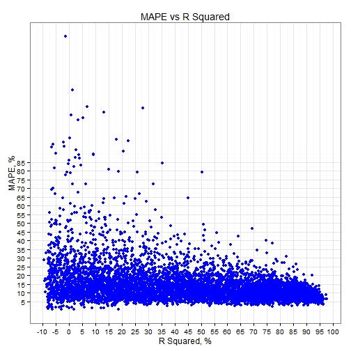

```r
ggplot(data = dataframe_all, aes(x=r_sq, y=mape))+
  geom_point(color = 'blue')+
  theme_bw() +
  xlab('R Squared, %') +
  ylab('MAPE, %') +
  ggtitle('MAPE vs R Squared') +
  scale_x_continuous(breaks=c(-10:20)*5)+
  scale_y_continuous(breaks=c(1:17)*5)
```

You can clearly see that for big R squared values MAPEs tend to be smaller, but we can't make good conclusions from this plot. So we tried couple of different approaches.

### Avg MAPE vs R-sq threshold

The first approach is the following: Instead of looking at the MAPEs for every particular value of R squared, we'll look at mean and median MAPEs for all R squared that are equal to or bigger than certain value.

Firstly we need to do some data preparation.

For values of R squared from 40% to 99.9% with a step of 0.5% we find mean and median of MAPE using “summary” function.

```r
threshold<-seq(40,99.9,0.5)

mape_stats <-
  data.frame(
    cbind(
      threshold,
      t(
        sapply(
          threshold,
          function(th)
            summary(subset(dataframe_all,r_sq>th)$mape)
        )
      )
    )
  )[,c('threshold','Median','Mean')]
head(mape_stats)
```

```
##   threshold Median  Mean
## 1      40.0  10.27 11.40
## 2      40.5  10.26 11.38
## 3      41.0  10.25 11.35
## 4      41.5  10.24 11.31
## 5      42.0  10.22 11.30
## 6      42.5  10.22 11.28
```

Now we have to change format of the data frame in order to build ggplot:

```r
median      <- data.frame(rep('Median', nrow(mape_stats)))
median_data <- cbind (mape_stats[,c('threshold','Median')],median)
names(median_data) <- c('threshold','StatValue','StatName')


mean      <- data.frame(rep('Mean', nrow(mape_stats)))
mean_data <- cbind (mape_stats[,c('threshold','Mean')],mean)
names(mean_data) <- c('threshold','StatValue','StatName')

mape_stats_processed <- rbind(median_data,mean_data)
mape_stats_processed$StatValue <- mape_stats_processed$StatValue
mape_stats_processed$threshold <- mape_stats_processed$threshold

head(mape_stats_processed)
```

```
##   threshold StatValue StatName
## 1      40.0     10.27   Median
## 2      40.5     10.26   Median
## 3      41.0     10.25   Median
## 4      41.5     10.24   Median
## 5      42.0     10.22   Median
## 6      42.5     10.22   Median
```

Now we are ready to build our plot:

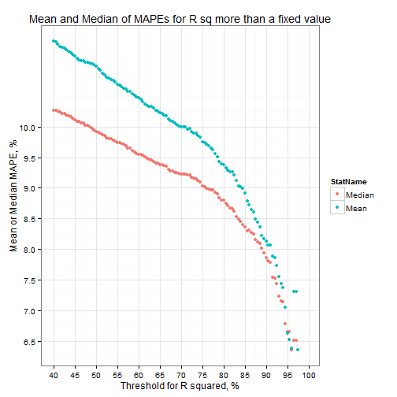

### Proportion of accounts with MAPE within a certain limit vs R-sq threshold

Let's now make another plot.

Our goal is to have MAPE of 6% or less, so let's build a plot, that shows probabilies for MAPE to be less than or equal to 6%. We'll plot other MAPE values for comparison as well.

Firstly, we prepare the data for plotting.

```r
# a function for calculating a proportion of accounts with MAPE within a specified limit (for different R-sq thresholds)
prob_data_for_mape <- function(x)
{
  prob_data_for_mape <-
    data.frame(
      cbind(
        x,
        threshold,
        sapply(
          threshold,
          function(th)
            length(subset(dataframe_all,r_sq>th & mape<=x)$mape)/length(subset(dataframe_all,r_sq>th)$mape)
        )
      )
    )

  names(prob_data_for_mape) <- c ('MAPE','threshold', 'prob')
  return(prob_data_for_mape)
}


# constructing proportions for different MAPE limits
prob_data_all_mapes <- rbind (prob_data_for_mape(4),
                              prob_data_for_mape(5),
                              prob_data_for_mape(6),
                              prob_data_for_mape(7),
                              prob_data_for_mape(8),
                              prob_data_for_mape(9),
                              prob_data_for_mape(10))


#prob_data_all_mapes$MAPE      <- prob_data_all_mapes$MAPE
prob_data_all_mapes$MAPE      <- factor(prob_data_all_mapes$MAPE, levels = c(10,9,8,7,6,5,4))
#prob_data_all_mapes$MAPE      <- factor(paste('\u2264', prob_data_all_mapes$MAPE, '%', sep =''))
prob_data_all_mapes$prob      <- prob_data_all_mapes$prob*100
prob_data_all_mapes$threshold <- prob_data_all_mapes$threshold
```

Now we are ready to build the plot:

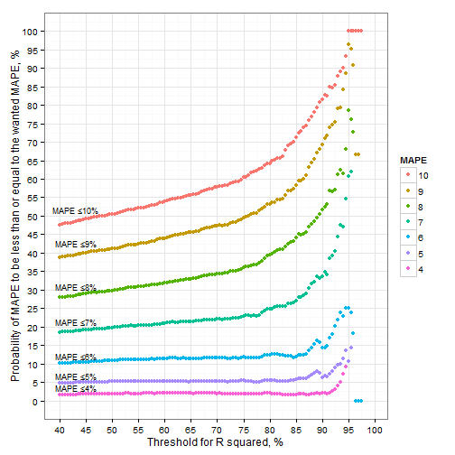